# explore source data for somatic aml

started: AL16May2018  
last updated: AL20May2018  
checked through: MG25May2018 on vep91 annotated data

### set text width and scrolling for html output

modified from here:  
https://stackoverflow.com/questions/36845178/width-of-r-code-chunk-output-in-rmarkdown-files-knitr-ed-to-html

# Summary

Explore total & allelic read depth in all cases, and in ref/alt and normal/tumours separately  
Explore alt fraction in all and in normals/tumours separately

The following filters were suggested after exploring the data:  
- Exclude variants with total depth in normals or in tumours < 20 (less than **1%** of variants)  
- Exclude variants where alt depth in normals > 1 (less than **1%** of variants)  
- Exclude variants with alt depth in tumours < 3 (about **9%** of variants)  
- Exclude variants with alt fraction in tumours < 10% (about **90%** of variants)

The percentage does not add to 100% because of filters are not applied and there is redundancy:  
some of the removed variants would be excluded by several filters at once

I decided not to explore ref-alt difference, because it is difficult to interpret  
An easier to interpret difference would be alt-in-tumour minus alt-in-normal  
However, this additinal filter is not necessary after 90% of variants excluded by the conventional alt fraction

Finally, this script selects a sub-group of somatic variants that were detected in more than one sample  
and makes separate tables for this sub-group

# start_section

```r
Sys.time()
```

```
## [1] "2018-05-25 16:11:49 BST"
```

```r
rm(list=ls())
graphics.off()

library(knitr)
base_folder="/rds/project/erf33/rds-erf33-medgen/users/mae/IHCAP75_atm_aml/ihcap_75_somatic_v2/filtering_somatic_with_AL_vep91/"
setwd(base_folder)
opts_knit$set(root.dir = base_folder)

#library(dplyr)
#opts_knit$set(width = 999)
```

# read_data

```r
gt_add.df <- read.table("/rds/project/erf33/rds-erf33-medgen/users/mae/IHCAP75_atm_aml/ihcap_75_somatic_v2/ihcap_75_somatic_v2_std_sma_ann_vep91_txt/ihcap_75_somatic_v2_std_sma_ann_v91_GT_add.txt", sep="\t", header=T)
ad.df <- read.table("/rds/project/erf33/rds-erf33-medgen/users/mae/IHCAP75_atm_aml/ihcap_75_somatic_v2/ihcap_75_somatic_v2_std_sma_ann_vep91_txt/ihcap_75_somatic_v2_std_sma_ann_v91_AD.txt", sep="\t", header=T)
vv.df <- read.table("/rds/project/erf33/rds-erf33-medgen/users/mae/IHCAP75_atm_aml/ihcap_75_somatic_v2/ihcap_75_somatic_v2_std_sma_ann_vep91_txt/ihcap_75_somatic_v2_std_sma_ann_v91_VV.txt", sep="\t", header=T)

#gt_chr.df <- read.table("/rds/project/erf33/rds-erf33-medgen/users/mae/IHCAP75_atm_aml/ihcap_75_somatic_v2/ihcap_75_somatic_v2_std_sma_ann_vep91_txt/ihcap_75_somatic_v2_std_sma_ann_v91_GT.txt", sep="\t", header=T)
#lod.df <- read.table("/rds/project/erf33/rds-erf33-medgen/users/mae/IHCAP75_atm_aml/ihcap_75_somatic_v2/ihcap_75_somatic_v2_std_sma_ann_vep91_txt/ihcap_75_somatic_v2_std_sma_ann_v91_LOD.txt", sep="\t", header=T)
#kgen.df <- read.table("/rds/project/erf33/rds-erf33-medgen/users/mae/IHCAP75_atm_aml/ihcap_75_somatic_v2/ihcap_75_somatic_v2_std_sma_ann_vep91_txt/ihcap_75_somatic_v2_std_sma_ann_v91_kgen.txt", sep="\t", header=T)
#exac.df <- read.table("/rds/project/erf33/rds-erf33-medgen/users/mae/IHCAP75_atm_aml/ihcap_75_somatic_v2/ihcap_75_somatic_v2_std_sma_ann_vep91_txt/ihcap_75_somatic_v2_std_sma_ann_v91_exac.txt", sep="\t", header=T)
```

# check_data

```r
dim(gt_add.df)
```

```
## [1] 7608    8
```

```r
str(gt_add.df)
```

```
## 'data.frame':    7608 obs. of  8 variables:
##  $ IHCAP75_1F_N.GT: int  NA NA 0 NA NA NA 0 NA NA NA ...
##  $ IHCAP75_1F_T.GT: int  NA NA 1 NA NA NA 1 NA NA NA ...
##  $ IHCAP75_BM_N.GT: int  NA 0 NA NA 0 NA NA 0 NA NA ...
##  $ IHCAP75_BM_T.GT: int  NA 1 NA NA 1 NA NA 1 NA NA ...
##  $ IHCAP75_T1_N.GT: int  NA NA NA 0 NA NA NA NA NA 0 ...
##  $ IHCAP75_T1_T.GT: int  NA NA NA 1 NA NA NA NA NA 1 ...
##  $ IHCAP75_T2_N.GT: int  0 NA NA NA NA 0 NA NA 0 NA ...
##  $ IHCAP75_T2_T.GT: int  1 NA NA NA NA 1 NA NA 1 NA ...
```

```r
colnames(gt_add.df) <- sub("\\.GT","",colnames(gt_add.df))
gt_add.df[1:5,1:5]
```

```
##              IHCAP75_1F_N IHCAP75_1F_T IHCAP75_BM_N IHCAP75_BM_T IHCAP75_T1_N
## Var000000001           NA           NA           NA           NA           NA
## Var000000002           NA           NA            0            1           NA
## Var000000003            0            1           NA           NA           NA
## Var000000004           NA           NA           NA           NA            0
## Var000000005           NA           NA            0            1           NA
```

```r
dim(ad.df)
```

```
## [1] 7608    9
```

```r
str(ad.df)
```

```
## 'data.frame':    7608 obs. of  9 variables:
##  $ SplitVarID     : Factor w/ 7608 levels "Var000000001",..: 1 2 3 4 5 6 7 8 9 10 ...
##  $ IHCAP75_1F_N.AD: Factor w/ 540 levels "100,0","100,1",..: NA NA 151 NA NA NA 342 NA NA NA ...
##  $ IHCAP75_1F_T.AD: Factor w/ 776 levels "0,2","10,2","10,4",..: NA NA 715 NA NA NA 189 NA NA NA ...
##  $ IHCAP75_BM_N.AD: Factor w/ 513 levels "10,0","100,0",..: NA 469 NA NA 408 NA NA 445 NA NA ...
##  $ IHCAP75_BM_T.AD: Factor w/ 863 levels "0,2","0,4","10,5",..: NA 650 NA NA 576 NA NA 690 NA NA ...
##  $ IHCAP75_T1_N.AD: Factor w/ 443 levels "100,0","100,1",..: NA NA NA 145 NA NA NA NA NA 436 ...
##  $ IHCAP75_T1_T.AD: Factor w/ 447 levels "0,2","10,14",..: NA NA NA 392 NA NA NA NA NA 320 ...
##  $ IHCAP75_T2_N.AD: Factor w/ 477 levels "100,0","100,1",..: 81 NA NA NA NA 93 NA NA 454 NA ...
##  $ IHCAP75_T2_T.AD: Factor w/ 539 levels "0,2","0,7","10,3",..: 512 NA NA NA NA 427 NA NA 204 NA ...
```

```r
colnames(ad.df) <- sub("\\.AD","",colnames(ad.df))
rownames(ad.df) <- ad.df[,1]
ad.df[1:5,1:5]
```

```
##                SplitVarID IHCAP75_1F_N IHCAP75_1F_T IHCAP75_BM_N IHCAP75_BM_T
## Var000000001 Var000000001         <NA>         <NA>         <NA>         <NA>
## Var000000002 Var000000002         <NA>         <NA>         77,0         54,4
## Var000000003 Var000000003        184,0         82,4         <NA>         <NA>
## Var000000004 Var000000004         <NA>         <NA>         <NA>         <NA>
## Var000000005 Var000000005         <NA>         <NA>         47,0         40,4
```

```r
dim(vv.df)
```

```
## [1] 7608   60
```

```r
str(vv.df)
```

```
## 'data.frame':    7608 obs. of  60 variables:
##  $ SplitVarID        : Factor w/ 7608 levels "Var000000001",..: 1 2 3 4 5 6 7 8 9 10 ...
##  $ ID                : Factor w/ 360 levels "rs10096369","rs10257529",..: NA NA NA NA NA NA NA NA NA NA ...
##  $ CHROM             : Factor w/ 23 levels "1","10","11",..: 1 1 1 1 1 1 1 1 1 1 ...
##  $ POS               : int  874425 876501 948942 948945 984346 987332 1078465 1114623 1139436 1229542 ...
##  $ REF               : Factor w/ 226 levels "A","AAAAAG","AAAAC",..: 59 59 59 59 59 59 59 59 59 59 ...
##  $ ALT               : Factor w/ 170 levels "A","AAAAAAAG",..: 68 1 1 1 1 123 1 1 1 71 ...
##  $ QUAL              : int  -10 -10 -10 -10 -10 -10 -10 -10 -10 -10 ...
##  $ FILTER            : Factor w/ 1 level "PASS": 1 1 1 1 1 1 1 1 1 1 ...
##  $ AC                : int  1 1 1 1 1 1 1 1 1 1 ...
##  $ AF                : num  0.25 0.25 0.25 0.25 0.25 0.25 0.25 0.25 0.25 0.25 ...
##  $ AN                : int  4 4 4 4 4 4 4 4 4 4 ...
##  $ Location          : Factor w/ 7608 levels "1:100330128",..: 739 740 760 761 768 769 16 39 52 86 ...
##  $ Allele            : Factor w/ 139 levels "-","A","AA","AAA",..: 133 2 2 2 2 112 2 2 2 76 ...
##  $ Uploaded_variation: Factor w/ 361 levels ".","rs10096369",..: 1 1 1 1 1 1 1 1 1 1 ...
```

[output cut: 46 more lines]

```r
rownames(vv.df) <- vv.df[,1]
vv.df[1:5,1:6]
```

```
##                SplitVarID   ID CHROM    POS REF  ALT
## Var000000001 Var000000001 <NA>     1 874425   C CTGT
## Var000000002 Var000000002 <NA>     1 876501   C    A
## Var000000003 Var000000003 <NA>     1 948942   C    A
## Var000000004 Var000000004 <NA>     1 948945   C    A
## Var000000005 Var000000005 <NA>     1 984346   C    A
```

```r
#dim(gt_chr.df)
#str(gt_chr.df)
#gt_chr.df[1:5,1:5]

#dim(lod.df)
#str(lod.df)
#lod.df[1:5,]

#dim(kgen.df)
#str(kgen.df)
#kgen.df[1:5,1:5]

#dim(exac.df)
#str(exac.df)
#exac.df[1:5,1:5]

# check that data are in sync
sum(rownames(gt_add.df) != rownames(ad.df))
```

```
## [1] 0
```

```r
sum(rownames(gt_add.df) != rownames(vv.df))
```

```
## [1] 0
```

```r
sum(colnames(gt_add.df) != colnames(ad.df[,-1]))
```

```
## [1] 0
```

# split ad table

```r
# Convert ad.df to character matrix with var ids in row names
ad.df[1:5,1:5]
```

```
##                SplitVarID IHCAP75_1F_N IHCAP75_1F_T IHCAP75_BM_N IHCAP75_BM_T
## Var000000001 Var000000001         <NA>         <NA>         <NA>         <NA>
## Var000000002 Var000000002         <NA>         <NA>         77,0         54,4
## Var000000003 Var000000003        184,0         82,4         <NA>         <NA>
## Var000000004 Var000000004         <NA>         <NA>         <NA>         <NA>
## Var000000005 Var000000005         <NA>         <NA>         47,0         40,4
```

```r
ad_chr.mx <- as.matrix(ad.df)
rownames(ad_chr.mx) <- ad.df$SplitVarID
ad_chr.mx <- ad_chr.mx[,-1]
ad_chr.mx[1:5,1:5]
```

```
##              IHCAP75_1F_N IHCAP75_1F_T IHCAP75_BM_N IHCAP75_BM_T IHCAP75_T1_N
## Var000000001 NA           NA           NA           NA           NA
## Var000000002 NA           NA           "77,0"       "54,4"       NA
## Var000000003 "184,0"      "82,4"       NA           NA           NA
## Var000000004 NA           NA           NA           NA           "190,0"
## Var000000005 NA           NA           "47,0"       "40,4"       NA
```

```r
# Split to two character matrices
ref_chr.mx <- sub(",.*","",ad_chr.mx)
alt_chr.mx <- sub(".*,","",ad_chr.mx)
ref_chr.mx[1:5,1:5]
```

```
##              IHCAP75_1F_N IHCAP75_1F_T IHCAP75_BM_N IHCAP75_BM_T IHCAP75_T1_N
## Var000000001 NA           NA           NA           NA           NA
## Var000000002 NA           NA           "77"         "54"         NA
## Var000000003 "184"        "82"         NA           NA           NA
## Var000000004 NA           NA           NA           NA           "190"
## Var000000005 NA           NA           "47"         "40"         NA
```

```r
alt_chr.mx[1:5,1:5]
```

```
##              IHCAP75_1F_N IHCAP75_1F_T IHCAP75_BM_N IHCAP75_BM_T IHCAP75_T1_N
## Var000000001 NA           NA           NA           NA           NA
## Var000000002 NA           NA           "0"          "4"          NA
## Var000000003 "0"          "4"          NA           NA           NA
## Var000000004 NA           NA           NA           NA           "0"
## Var000000005 NA           NA           "0"          "4"          NA
```

```r
# Convert character matrices to numeric
dp_ref.mx <- matrix(as.numeric(ref_chr.mx), ncol=ncol(ref_chr.mx))
rownames(dp_ref.mx) <- rownames(ref_chr.mx)
colnames(dp_ref.mx) <- colnames(ref_chr.mx)
dp_ref.mx[1:5,1:5]
```

```
##              IHCAP75_1F_N IHCAP75_1F_T IHCAP75_BM_N IHCAP75_BM_T IHCAP75_T1_N
## Var000000001           NA           NA           NA           NA           NA
## Var000000002           NA           NA           77           54           NA
## Var000000003          184           82           NA           NA           NA
## Var000000004           NA           NA           NA           NA          190
## Var000000005           NA           NA           47           40           NA
```

```r
dp_alt.mx <- matrix(as.numeric(alt_chr.mx), ncol=ncol(alt_chr.mx))
rownames(dp_alt.mx) <- rownames(alt_chr.mx)
colnames(dp_alt.mx) <- colnames(alt_chr.mx)
dp_alt.mx[1:5,1:5]
```

```
##              IHCAP75_1F_N IHCAP75_1F_T IHCAP75_BM_N IHCAP75_BM_T IHCAP75_T1_N
## Var000000001           NA           NA           NA           NA           NA
## Var000000002           NA           NA            0            4           NA
## Var000000003            0            4           NA           NA           NA
## Var000000004           NA           NA           NA           NA            0
## Var000000005           NA           NA            0            4           NA
```

```r
# make total depth matrix
dp.mx <- dp_ref.mx + dp_alt.mx
dp.mx[1:5,1:5]
```

```
##              IHCAP75_1F_N IHCAP75_1F_T IHCAP75_BM_N IHCAP75_BM_T IHCAP75_T1_N
## Var000000001           NA           NA           NA           NA           NA
## Var000000002           NA           NA           77           58           NA
## Var000000003          184           86           NA           NA           NA
## Var000000004           NA           NA           NA           NA          190
## Var000000005           NA           NA           47           44           NA
```

```r
# make alt fraction matrix
alt_fraction.mx <- dp_alt.mx / dp.mx

# clean-up
rm(ad_chr.mx, ref_chr.mx, alt_chr.mx)
```

# explore depth

Look separately in  
- REF, ALT and REF+ALT  
- all, normal(s) and tumours

## All 8 columns - for orientation only

```r
# cumulative depth
mean(dp.mx, na.rm=T)
```

```
## [1] 122.6343
```

```r
median(dp.mx, na.rm=T)
```

```
## [1] 101
```

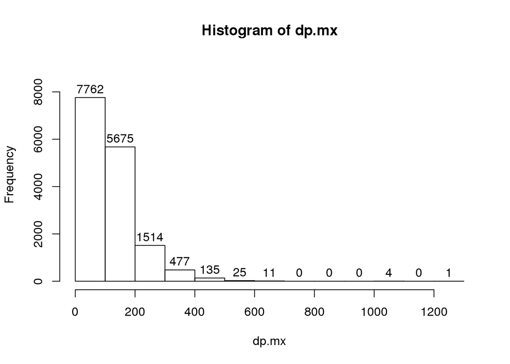

```r
hist(dp.mx, labels = T, ylim=c(0,9000))
```

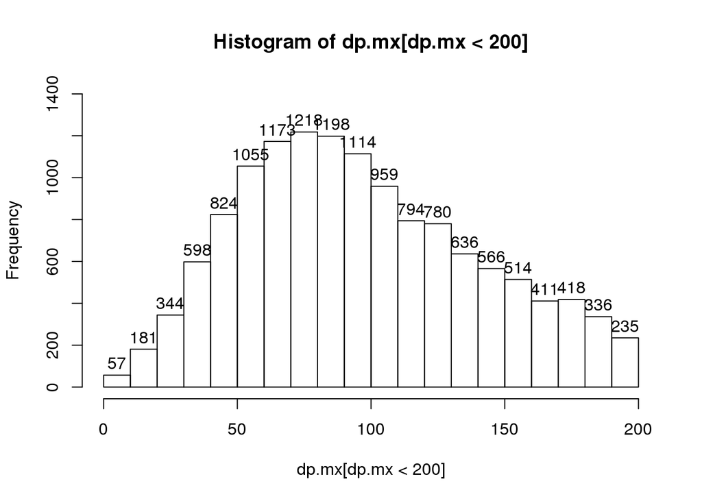

```r
hist(dp.mx[dp.mx<200], labels = T, ylim=c(0,1400))
```

```r
# explore cases with high depth
too_high_dp <- unique(which(dp.mx>500)%%nrow(dp.mx))
length(too_high_dp) # 31
```

```
## [1] 31
```

```r
ad.df[too_high_dp,]
```

```
##                SplitVarID IHCAP75_1F_N IHCAP75_1F_T IHCAP75_BM_N IHCAP75_BM_T IHCAP75_T1_N IHCAP75_T1_T IHCAP75_T2_N IHCAP75_T2_T
## Var000000415 Var000000415        514,0        358,6         <NA>         <NA>         <NA>         <NA>         <NA>         <NA>
## Var000002031 Var000002031        512,0        438,7         <NA>         <NA>         <NA>         <NA>         <NA>         <NA>
## Var000004348 Var000004348        531,0        414,5         <NA>         <NA>         <NA>         <NA>         <NA>         <NA>
## Var000004734 Var000004734        695,0        559,4         <NA>         <NA>         <NA>         <NA>         <NA>         <NA>
## Var000005156 Var000005156        517,1        480,4         <NA>         <NA>         <NA>         <NA>         <NA>         <NA>
## Var000005313 Var000005313      347,254      261,132         <NA>         <NA>         <NA>         <NA>         <NA>         <NA>
## Var000005408 Var000005408        528,1        386,5         <NA>         <NA>         <NA>         <NA>         <NA>         <NA>
## Var000005630 Var000005630        611,0        539,7         <NA>         <NA>         <NA>         <NA>         <NA>         <NA>
## Var000006321 Var000006321      418,200       297,85         <NA>         <NA>         <NA>         <NA>         <NA>         <NA>
## Var000006400 Var000006400       1012,0      443,212       1005,0      546,152       1002,0       266,70       1007,0       282,95
## Var000006978 Var000006978        506,0        408,5         <NA>         <NA>         <NA>         <NA>         <NA>         <NA>
## Var000007076 Var000007076        518,0        362,4         <NA>         <NA>         <NA>         <NA>         <NA>         <NA>
## Var000000506 Var000000506         <NA>         <NA>        579,0        448,5         <NA>         <NA>         <NA>         <NA>
## Var000001718 Var000001718         <NA>         <NA>        536,0        378,6         <NA>         <NA>         <NA>         <NA>
## Var000002140 Var000002140         <NA>         <NA>        536,0        539,5         <NA>         <NA>         <NA>         <NA>
## Var000002770 Var000002770         <NA>         <NA>        519,0        526,4         <NA>         <NA>         <NA>         <NA>
## Var000004116 Var000004116         <NA>         <NA>        501,0        382,4         <NA>         <NA>         <NA>         <NA>
## Var000004774 Var000004774         <NA>         <NA>        525,1        410,6         <NA>         <NA>         <NA>         <NA>
## Var000005707 Var000005707         <NA>         <NA>        634,0        464,6         <NA>         <NA>         <NA>         <NA>
## Var000006982 Var000006982         <NA>         <NA>        568,0        499,6         <NA>         <NA>         <NA>         <NA>
## Var000000755 Var000000755         <NA>         <NA>        432,1        581,4         <NA>         <NA>         <NA>         <NA>
## Var000001819 Var000001819         <NA>         <NA>         <NA>         <NA>        586,0        321,6         <NA>         <NA>
## Var000002396 Var000002396         <NA>         <NA>         <NA>         <NA>        501,0        115,4         <NA>         <NA>
## Var000002941 Var000002941         <NA>         <NA>         <NA>         <NA>        508,0        238,6         <NA>         <NA>
## Var000003650 Var000003650         <NA>         <NA>         <NA>         <NA>        604,0        260,4         <NA>         <NA>
## Var000003769 Var000003769         <NA>         <NA>         <NA>         <NA>        608,0        242,5         <NA>         <NA>
## Var000005310 Var000005310         <NA>         <NA>         <NA>         <NA>        522,0         68,4         <NA>         <NA>
## Var000005698 Var000005698         <NA>         <NA>         <NA>         <NA>        619,0         80,4         <NA>         <NA>
## Var000000954 Var000000954         <NA>         <NA>         <NA>         <NA>         <NA>         <NA>        564,0        304,4
## Var000003623 Var000003623         <NA>         <NA>         <NA>         <NA>         <NA>         <NA>        605,1        263,5
## Var000005789 Var000005789         <NA>         <NA>         <NA>         <NA>         <NA>         <NA>      1170,76        432,6
```

```r
# a reference suggesting explanation for the vagueness of AD counts in normal for variant Var000006400:
# https://software.broadinstitute.org/gatk/documentation/tooldocs/3.8-0/org_broadinstitute_gatk_tools_walkers_annotator_DepthPerAlleleBySample.php
# decided to keep the too high read depth for Var000006400 - of interest
vv.df[ad.df[too_high_dp,"SplitVarID"],c("SplitVarID","SYMBOL","Consequence","CLIN_SIG")]
```

```
##                SplitVarID        SYMBOL                          Consequence CLIN_SIG
## Var000000415 Var000000415       PDE4DIP                  5_prime_UTR_variant     <NA>
## Var000002031 Var000002031        SH3D19                     missense_variant     <NA>
## Var000004348 Var000004348       TMEM135                     missense_variant     <NA>
## Var000004734 Var000004734          TPH2                   synonymous_variant     <NA>
## Var000005156 Var000005156           MAX                       intron_variant     <NA>
## Var000005313 Var000005313       GOLGA8R                     missense_variant     <NA>
## Var000005408 Var000005408       LDHAL6B                     missense_variant     <NA>
## Var000005630 Var000005630          NDE1                     missense_variant     <NA>
## Var000006321 Var000006321 RP11-683L23.1                   frameshift_variant     <NA>
## Var000006400 Var000006400        TCEB3B                     missense_variant     <NA>
## Var000006978 Var000006978       EPB41L1                       intron_variant     <NA>
## Var000007076 Var000007076          TPTE                       intron_variant     <NA>
## Var000000506 Var000000506        CCDC19                     missense_variant     <NA>
## Var000001718 Var000001718        EIF4G1 splice_region_variant&intron_variant     <NA>
## Var000002140 Var000002140         SPEF2                     missense_variant     <NA>
## Var000002770 Var000002770          TCP1                     missense_variant     <NA>
## Var000004116 Var000004116          LDHA                   synonymous_variant   benign
## Var000004774 Var000004774       SLC17A8                     missense_variant     <NA>
## Var000005707 Var000005707        ABCC12                     missense_variant     <NA>
## Var000006982 Var000006982        SAMHD1                     missense_variant     <NA>
## Var000000755 Var000000755       SDCCAG8                     missense_variant     <NA>
## Var000001819 Var000001819        SLC2A9                   synonymous_variant     <NA>
## Var000002396 Var000002396       GMCL1P1   non_coding_transcript_exon_variant     <NA>
## Var000002941 Var000002941         ABCB1                   synonymous_variant     <NA>
## Var000003650 Var000003650          SETX                   frameshift_variant     <NA>
## Var000003769 Var000003769        NAMPTL                upstream_gene_variant     <NA>
## Var000005310 Var000005310       GOLGA8M                       intron_variant     <NA>
## Var000005698 Var000005698      SLC6A10P   non_coding_transcript_exon_variant     <NA>
## Var000000954 Var000000954       EIF2AK3                     inframe_deletion     <NA>
## Var000003623 Var000003623        SPTAN1                   synonymous_variant     <NA>
## Var000005789 Var000005789       NPIPB15                     missense_variant     <NA>
```

```r
# depth in ref
mean(dp_ref.mx, na.rm=T)
```

```
## [1] 120.2674
```

```r
median(dp_ref.mx, na.rm=T)
```

```
## [1] 99
```

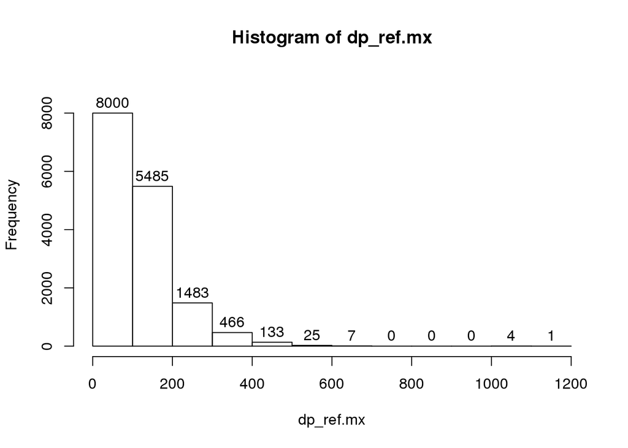

```r
hist(dp_ref.mx, labels = T, ylim=c(0,9000))
```

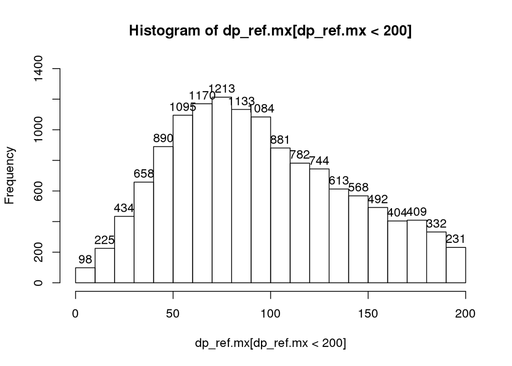

```r
hist(dp_ref.mx[dp_ref.mx<200], labels = T, ylim=c(0,1400))
```

```r
# depth in alt
mean(dp_alt.mx, na.rm=T)
```

```
## [1] 2.366893
```

```r
median(dp_alt.mx, na.rm=T)
```

```
## [1] 1
```

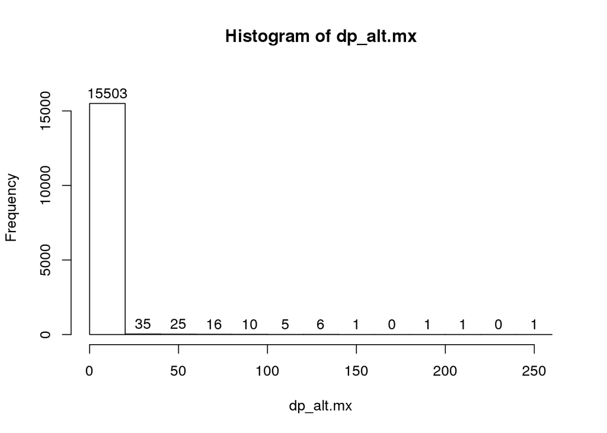

```
##  [1]   0  20  40  60  80 100 120 140 160 180 200 220 240 260
```

```r
hist(dp_alt.mx, labels = T, ylim=c(0,17000))$breaks
```

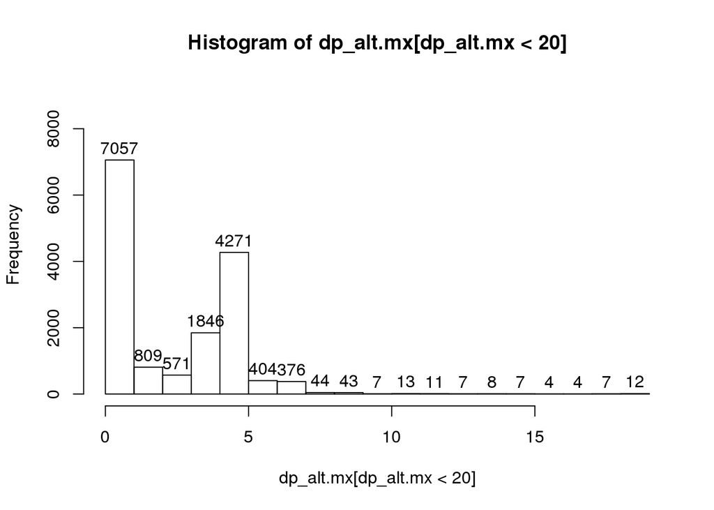

```r
hist(dp_alt.mx[dp_alt.mx<20], labels = T, ylim=c(0,9000), right=F) # left-open, right-closed (see ?hist)
```

```r
sum(dp_alt.mx==0, na.rm=T)
```

```
## [1] 7057
```

```r
sum(dp_alt.mx==1, na.rm=T)
```

```
## [1] 809
```

```r
sum(dp_alt.mx==3, na.rm=T)
```

```
## [1] 1846
```

```r
sum(dp_alt.mx==4, na.rm=T)
```

```
## [1] 4271
```

```r
sum(dp_alt.mx==5, na.rm=T)
```

```
## [1] 404
```

```r
rm(too_high_dp)
```

## depth in normal(s)

Suggestion: - keep only variants with at least 20 overall reads in normals  
- exclude variants with ALT depth in normals > 1

```r
# select columns
normals <- c("IHCAP75_1F_N", "IHCAP75_BM_N", "IHCAP75_T1_N", "IHCAP75_T2_N")

# cumulative depth
dp_normals.mx <- dp.mx[,normals]
dim(dp_normals.mx)
```

```
## [1] 7608    4
```

```r
mean(dp_normals.mx, na.rm=T)
```

```
## [1] 151.2453
```

```r
median(dp_normals.mx, na.rm=T)
```

```
## [1] 132
```

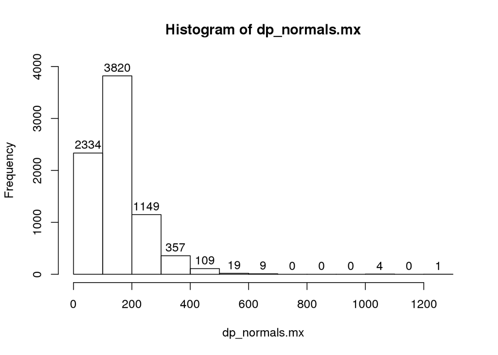

```r
hist(dp_normals.mx, labels = T, ylim=c(0,4000))
```

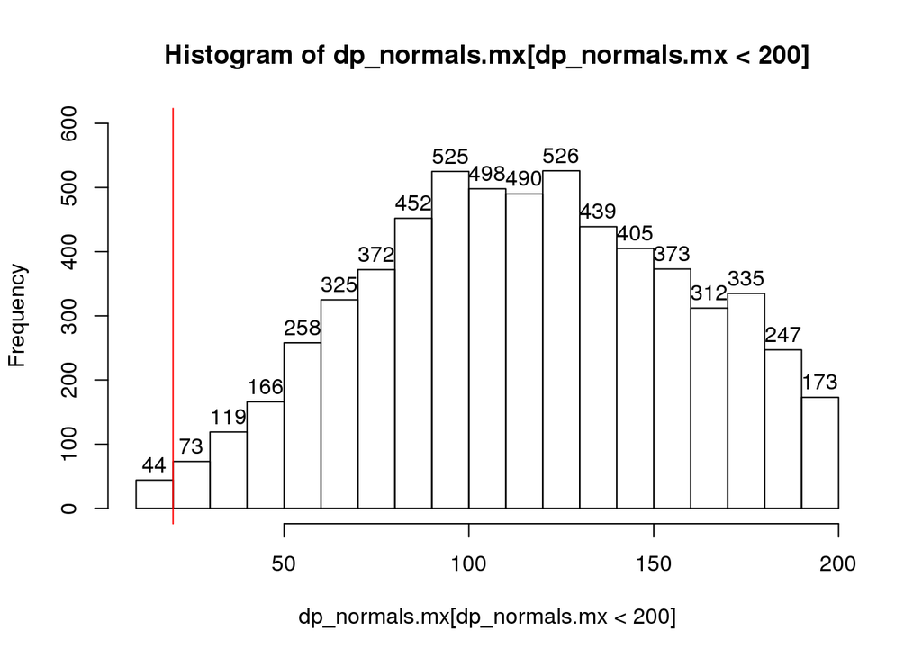

```r
hist(dp_normals.mx[dp_normals.mx<200], labels = T, ylim=c(0,600))
abline(v=20, col="RED")
```

```r
total <- sum(!is.na(dp_normals.mx))
total
```

```
## [1] 7802
```

```r
excluded <- 44
excluded
```

```
## [1] 44
```

```r
excluded/total
```

```
## [1] 0.00563958
```

```r
# depth in ref
dp_ref_normals.mx <- dp_ref.mx[,normals]
dim(dp_ref_normals.mx)
```

```
## [1] 7608    4
```

```r
mean(dp_ref_normals.mx, na.rm=T)
```

```
## [1] 151.0185
```

```r
median(dp_ref_normals.mx, na.rm=T)
```

```
## [1] 131.5
```

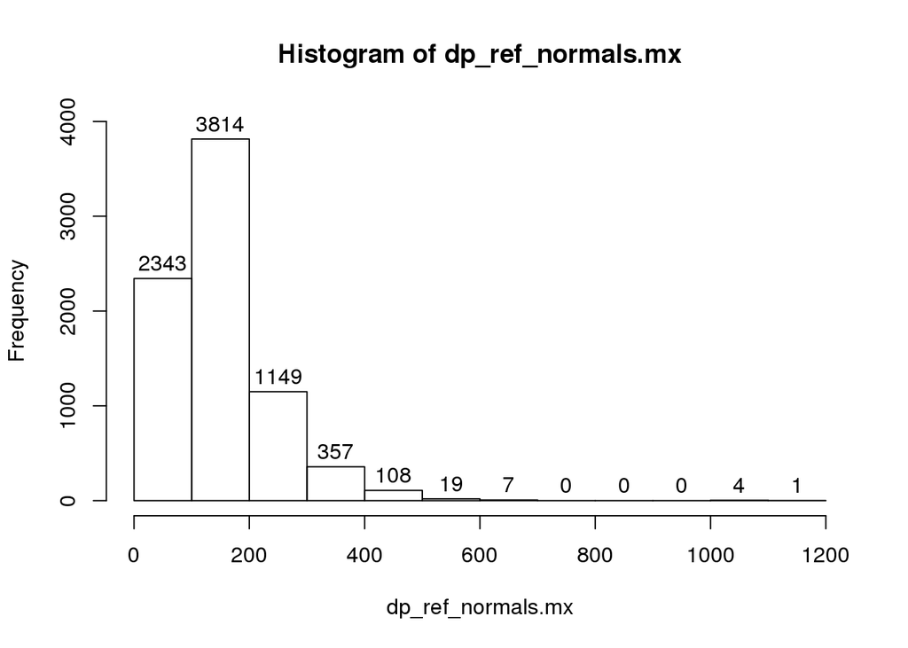

```r
hist(dp_ref_normals.mx, labels = T, ylim=c(0,4000))
```

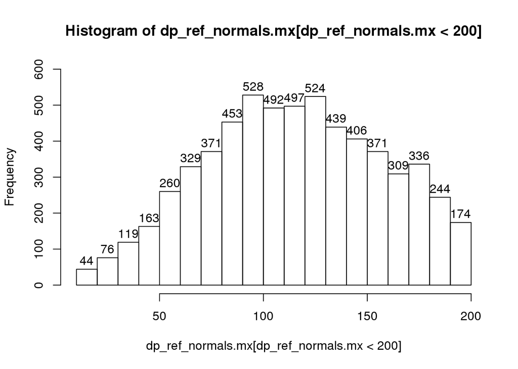

```r
hist(dp_ref_normals.mx[dp_ref_normals.mx<200], labels = T, ylim=c(0,600))
```

```r
# depth in alt
dp_alt_normals.mx <- dp_alt.mx[,normals]
dim(dp_alt_normals.mx)
```

```
## [1] 7608    4
```

```r
mean(dp_alt_normals.mx, na.rm=T)
```

```
## [1] 0.2268649
```

```r
median(dp_alt_normals.mx, na.rm=T)
```

```
## [1] 0
```

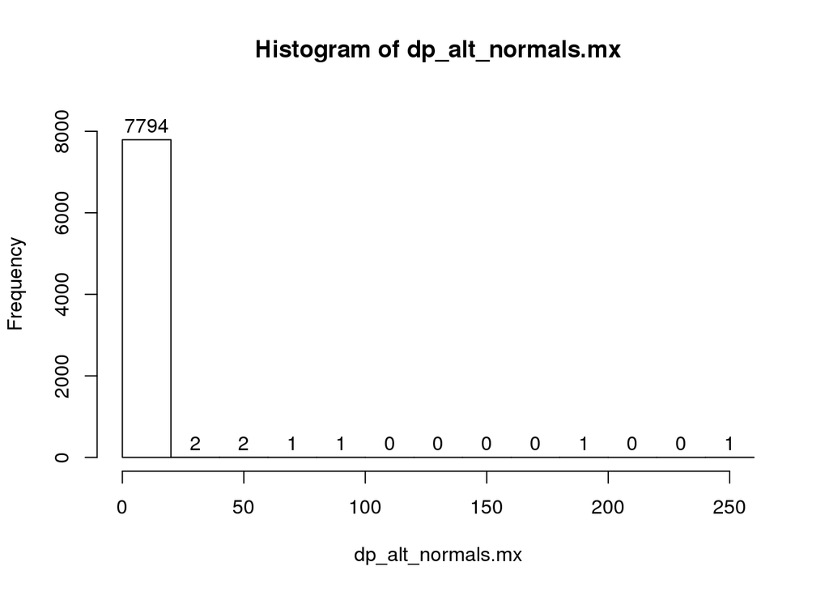

```
##  [1]   0  20  40  60  80 100 120 140 160 180 200 220 240 260
```

```r
hist(dp_alt_normals.mx, labels = T, ylim=c(0,8500))$breaks
```

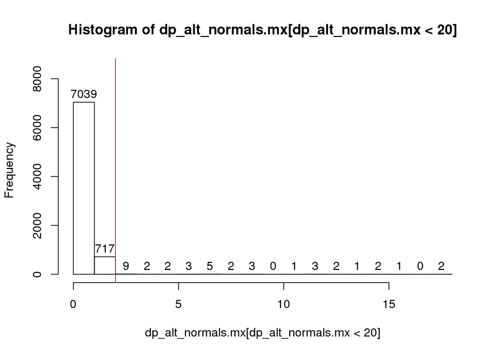

```r
hist(dp_alt_normals.mx[dp_alt_normals.mx<20], labels = T, ylim=c(0,8500), right=F) # left-open, right-closed (see ?hist)
abline(v=2, col="RED") # 2 means 1 because right=F : left-open, right-closed
```

```r
table(dp_alt_normals.mx)
```

```
## dp_alt_normals.mx
##    0    1    2    3    4    5    6    7    8   10   11   12   13   14   15   17   18   34   45   46   76   91  200  254
## 7039  717    9    2    2    3    5    2    3    1    3    2    1    2    1    1    1    2    1    1    1    1    1    1
```

```r
total <- sum(!is.na(dp_alt_normals.mx))
total
```

```
## [1] 7802
```

```r
excluded <- total-7039-717
excluded
```

```
## [1] 46
```

```r
excluded/total
```

```
## [1] 0.005895924
```

```r
# --- explore cases with high ALT depth in normals --- #

# dp in normals = 2
high_alt_in_normals <- unique(which(dp_alt_normals.mx==2)%%nrow(dp_alt_normals.mx))
ad.df[high_alt_in_normals,]
```

```
##                SplitVarID IHCAP75_1F_N IHCAP75_1F_T IHCAP75_BM_N IHCAP75_BM_T IHCAP75_T1_N IHCAP75_T1_T IHCAP75_T2_N IHCAP75_T2_T
## Var000000762 Var000000762         67,2         57,5         <NA>         <NA>         <NA>         <NA>         <NA>         <NA>
## Var000000781 Var000000781        148,2        143,7         <NA>         <NA>         <NA>         <NA>         <NA>         <NA>
## Var000001799 Var000001799        257,2        307,7         <NA>         <NA>         <NA>         <NA>         <NA>         <NA>
## Var000002042 Var000002042         67,2         54,3         <NA>         <NA>         <NA>         <NA>         <NA>         <NA>
## Var000002505 Var000002505        120,2         79,4         <NA>         <NA>         <NA>         <NA>         <NA>         <NA>
## Var000004722 Var000004722         69,2         54,5         <NA>         <NA>         <NA>         <NA>         <NA>         <NA>
## Var000005333 Var000005333        106,2         88,8         <NA>         <NA>         <NA>         <NA>         <NA>         <NA>
## Var000004327 Var000004327         <NA>         <NA>         89,2         98,4         <NA>         <NA>         <NA>         <NA>
## Var000001413 Var000001413         <NA>         <NA>         <NA>         <NA>         <NA>         <NA>        100,2         32,7
```

```r
vv.df[ad.df[high_alt_in_normals,"SplitVarID"],c("SplitVarID","SYMBOL","Consequence","CLIN_SIG")]
```

```
##                SplitVarID  SYMBOL                          Consequence CLIN_SIG
## Var000000762 Var000000762  AHCTF1 splice_region_variant&intron_variant     <NA>
## Var000000781 Var000000781   ROCK2 splice_region_variant&intron_variant     <NA>
## Var000001799 Var000001799   OTOP1                       intron_variant     <NA>
## Var000002042 Var000002042    MND1                       intron_variant     <NA>
## Var000002505 Var000002505 C6orf10                       intron_variant     <NA>
## Var000004722 Var000004722    IFNG splice_region_variant&intron_variant     <NA>
## Var000005333 Var000005333     BMF                       intron_variant     <NA>
## Var000004327 Var000004327   SPCS2                       intron_variant     <NA>
## Var000001413 Var000001413  ZBTB47                   frameshift_variant     <NA>
```

```r
# dp in normals = 3
high_alt_in_normals <- unique(which(dp_alt_normals.mx==3)%%nrow(dp_alt_normals.mx))
ad.df[high_alt_in_normals,]
```

```
##                SplitVarID IHCAP75_1F_N IHCAP75_1F_T IHCAP75_BM_N IHCAP75_BM_T IHCAP75_T1_N IHCAP75_T1_T IHCAP75_T2_N IHCAP75_T2_T
## Var000001669 Var000001669         <NA>         <NA>        141,3        128,7         <NA>         <NA>         <NA>         <NA>
## Var000002852 Var000002852         <NA>         <NA>         55,3         39,4         <NA>         <NA>         <NA>         <NA>
```

```r
vv.df[ad.df[high_alt_in_normals,"SplitVarID"],c("SplitVarID","SYMBOL","Consequence","CLIN_SIG")]
```

```
##                SplitVarID    SYMBOL             Consequence               CLIN_SIG
## Var000001669 Var000001669     CLRN1 downstream_gene_variant uncertain_significance
## Var000002852 Var000002852 ADCYAP1R1          intron_variant                   <NA>
```

```r
# dp in normals = 4
high_alt_in_normals <- unique(which(dp_alt_normals.mx==4)%%nrow(dp_alt_normals.mx))
ad.df[high_alt_in_normals,]
```

```
##                SplitVarID IHCAP75_1F_N IHCAP75_1F_T IHCAP75_BM_N IHCAP75_BM_T IHCAP75_T1_N IHCAP75_T1_T IHCAP75_T2_N IHCAP75_T2_T
## Var000005290 Var000005290        105,4         71,6         <NA>         <NA>         <NA>         <NA>         <NA>         <NA>
## Var000004606 Var000004606         <NA>         <NA>        116,4         84,9         <NA>         <NA>         <NA>         <NA>
```

```r
vv.df[ad.df[high_alt_in_normals,"SplitVarID"],c("SplitVarID","SYMBOL","Consequence","CLIN_SIG")]
```

```
##                SplitVarID   SYMBOL        Consequence CLIN_SIG
## Var000005290 Var000005290    IGHJ6 frameshift_variant     <NA>
## Var000004606 Var000004606 C12orf68  inframe_insertion     <NA>
```

```r
# dp in normals = 5
high_alt_in_normals <- unique(which(dp_alt_normals.mx==5)%%nrow(dp_alt_normals.mx))
ad.df[high_alt_in_normals,]
```

```
##                SplitVarID IHCAP75_1F_N IHCAP75_1F_T IHCAP75_BM_N IHCAP75_BM_T IHCAP75_T1_N IHCAP75_T1_T IHCAP75_T2_N IHCAP75_T2_T
## Var000001587 Var000001587         <NA>         <NA>        112,5         80,5         <NA>         <NA>         <NA>         <NA>
## Var000002683 Var000002683         <NA>         <NA>         38,5         38,6         <NA>         <NA>         <NA>         <NA>
## Var000003872 Var000003872         <NA>         <NA>         <NA>         <NA>        139,5        61,11         <NA>         <NA>
```

```r
vv.df[ad.df[high_alt_in_normals,"SplitVarID"],c("SplitVarID","SYMBOL","Consequence","CLIN_SIG")]
```

```
##                SplitVarID SYMBOL    Consequence CLIN_SIG
## Var000001587 Var000001587 POPDC2 intron_variant     <NA>
## Var000002683 Var000002683 NKAIN2 intron_variant     <NA>
## Var000003872 Var000003872   MYOF intron_variant     <NA>
```

```r
# dp in normals > 5
high_alt_in_normals <- unique(which(dp_alt_normals.mx>5)%%nrow(dp_alt_normals.mx))
length (high_alt_in_normals) # 30
```

```
## [1] 30
```

```r
ad.df[high_alt_in_normals,]
```

```
##                SplitVarID IHCAP75_1F_N IHCAP75_1F_T IHCAP75_BM_N IHCAP75_BM_T IHCAP75_T1_N IHCAP75_T1_T IHCAP75_T2_N IHCAP75_T2_T
## Var000001727 Var000001727         51,7         63,6         <NA>         <NA>         <NA>         <NA>         <NA>         <NA>
## Var000001757 Var000001757       104,18       120,11         <NA>         <NA>         <NA>         <NA>         <NA>         <NA>
## Var000002859 Var000002859        60,46        44,41         <NA>         <NA>         <NA>         <NA>         <NA>         <NA>
## Var000004513 Var000004513       119,13        39,18         <NA>         <NA>         <NA>         <NA>         <NA>         <NA>
## Var000005313 Var000005313      347,254      261,132         <NA>         <NA>         <NA>         <NA>         <NA>         <NA>
## Var000006296 Var000006296        74,34        41,41         <NA>         <NA>         <NA>         <NA>         <NA>         <NA>
## Var000006321 Var000006321      418,200       297,85         <NA>         <NA>         <NA>         <NA>         <NA>         <NA>
## Var000007360 Var000007360       371,17       214,14         <NA>         <NA>         <NA>         <NA>         <NA>         <NA>
## Var000003464 Var000003464         <NA>         <NA>        29,15        30,24         <NA>         <NA>         <NA>         <NA>
## Var000004366 Var000004366         <NA>         <NA>         68,6         51,8         <NA>         <NA>         <NA>         <NA>
## Var000004427 Var000004427         <NA>         <NA>       106,12        63,19         <NA>         <NA>         <NA>         <NA>
## Var000004905 Var000004905         <NA>         <NA>       215,91       211,18         <NA>         <NA>         <NA>         <NA>
## Var000005058 Var000005058         <NA>         <NA>       144,14       108,12         <NA>         <NA>         <NA>         <NA>
## Var000006219 Var000006219         <NA>         <NA>       241,11       218,12         <NA>         <NA>         <NA>         <NA>
## Var000006361 Var000006361         <NA>         <NA>         98,8        99,18         <NA>         <NA>         <NA>         <NA>
## Var000000126 Var000000126         <NA>         <NA>         <NA>         <NA>       296,34       127,16         <NA>         <NA>
## Var000000570 Var000000570         <NA>         <NA>         <NA>         <NA>         51,6          3,4         <NA>         <NA>
## Var000001017 Var000001017         <NA>         <NA>         <NA>         <NA>        193,6         50,4         <NA>         <NA>
## Var000001825 Var000001825         <NA>         <NA>         <NA>         <NA>        23,11         21,6         <NA>         <NA>
## Var000002112 Var000002112         <NA>         <NA>         <NA>         <NA>       397,10        201,6         <NA>         <NA>
## Var000003109 Var000003109         <NA>         <NA>         <NA>         <NA>        411,7        111,2         <NA>         <NA>
## Var000005174 Var000005174         <NA>         <NA>         <NA>         <NA>         97,6         17,4         <NA>         <NA>
## Var000005316 Var000005316         <NA>         <NA>         <NA>         <NA>       336,14         59,9         <NA>         <NA>
## Var000005699 Var000005699         <NA>         <NA>         <NA>         <NA>         61,8          9,4         <NA>         <NA>
## Var000000845 Var000000845         <NA>         <NA>         <NA>         <NA>         <NA>         <NA>        232,6       109,11
## Var000000956 Var000000956         <NA>         <NA>         <NA>         <NA>         <NA>         <NA>        381,8       222,14
## Var000002022 Var000002022         <NA>         <NA>         <NA>         <NA>         <NA>         <NA>       177,12         41,8
## Var000004553 Var000004553         <NA>         <NA>         <NA>         <NA>         <NA>         <NA>       119,45        84,31
## Var000005789 Var000005789         <NA>         <NA>         <NA>         <NA>         <NA>         <NA>      1170,76        432,6
## Var000006758 Var000006758         <NA>         <NA>         <NA>         <NA>         <NA>         <NA>       176,11        85,13
```

```r
vv.df[ad.df[high_alt_in_normals,"SplitVarID"],c("SplitVarID","SYMBOL","Consequence","CLIN_SIG")]
```

```
##                SplitVarID        SYMBOL                          Consequence CLIN_SIG
## Var000001727 Var000001727          ETV5                       intron_variant     <NA>
## Var000001757 Var000001757      TCTEX1D2                       intron_variant     <NA>
## Var000002859 Var000002859        NT5C3A                  3_prime_UTR_variant     <NA>
## Var000004513 Var000004513        ZNF384                     inframe_deletion     <NA>
## Var000005313 Var000005313       GOLGA8R                     missense_variant     <NA>
## Var000006296 Var000006296        BAIAP2                       intron_variant     <NA>
## Var000006321 Var000006321 RP11-683L23.1                   frameshift_variant     <NA>
## Var000007360 Var000007360     SUPT20HL1   non_coding_transcript_exon_variant     <NA>
## Var000003464 Var000003464      ANKRD18A              downstream_gene_variant     <NA>
## Var000004366 Var000004366         MAML2                   frameshift_variant     <NA>
## Var000004427 Var000004427         CXCR5                       intron_variant     <NA>
## Var000004905 Var000004905        PABPC3                     missense_variant     <NA>
## Var000005058 Var000005058         RBM23                   frameshift_variant     <NA>
## Var000006219 Var000006219       PRKAR1A                       intron_variant     <NA>
## Var000006361 Var000006361         ESCO1 splice_region_variant&intron_variant     <NA>
## Var000000126 Var000000126         HSPG2                    inframe_insertion     <NA>
## Var000000570 Var000000570        SEC16B                     missense_variant     <NA>
## Var000001017 Var000001017       TMEM177                   frameshift_variant     <NA>
## Var000001825 Var000001825         CPEB2                    inframe_insertion     <NA>
## Var000002112 Var000002112         DNAH5                   frameshift_variant     <NA>
## Var000003109 Var000003109       ARHGEF5                           start_lost     <NA>
## Var000005174 Var000005174          RGS6                       intron_variant     <NA>
## Var000005316 Var000005316         TRPM1                   frameshift_variant     <NA>
## Var000005699 Var000005699         VPS35                       intron_variant     <NA>
## Var000000845 Var000000845           XDH                       intron_variant     <NA>
## Var000000956 Var000000956       EIF2AK3                   frameshift_variant     <NA>
## Var000002022 Var000002022          GYPA                    inframe_insertion     <NA>
## Var000004553 Var000004553          LDHB splice_region_variant&intron_variant     <NA>
## Var000005789 Var000005789       NPIPB15                     missense_variant     <NA>
## Var000006758 Var000006758        ZNF233                   frameshift_variant     <NA>
```

```r
# Clean-up
rm(normals, dp_normals.mx, dp_ref_normals.mx, dp_alt_normals.mx, high_alt_in_normals, total, excluded)
```

## depth in tumours

Suggestions: keep only variants with  
- at least 20 overall reads in tumour  
- at least 3 reads supporting ALT

```r
# select columns
tumours <- c("IHCAP75_1F_T", "IHCAP75_BM_T", "IHCAP75_T1_T", "IHCAP75_T2_T")

# cumulative depth
dp_tumours.mx <- dp.mx[,tumours]
dim(dp_tumours.mx)
```

```
## [1] 7608    4
```

```r
mean(dp_tumours.mx, na.rm=T)
```

```
## [1] 94.0232
```

```r
median(dp_tumours.mx, na.rm=T)
```

```
## [1] 78
```

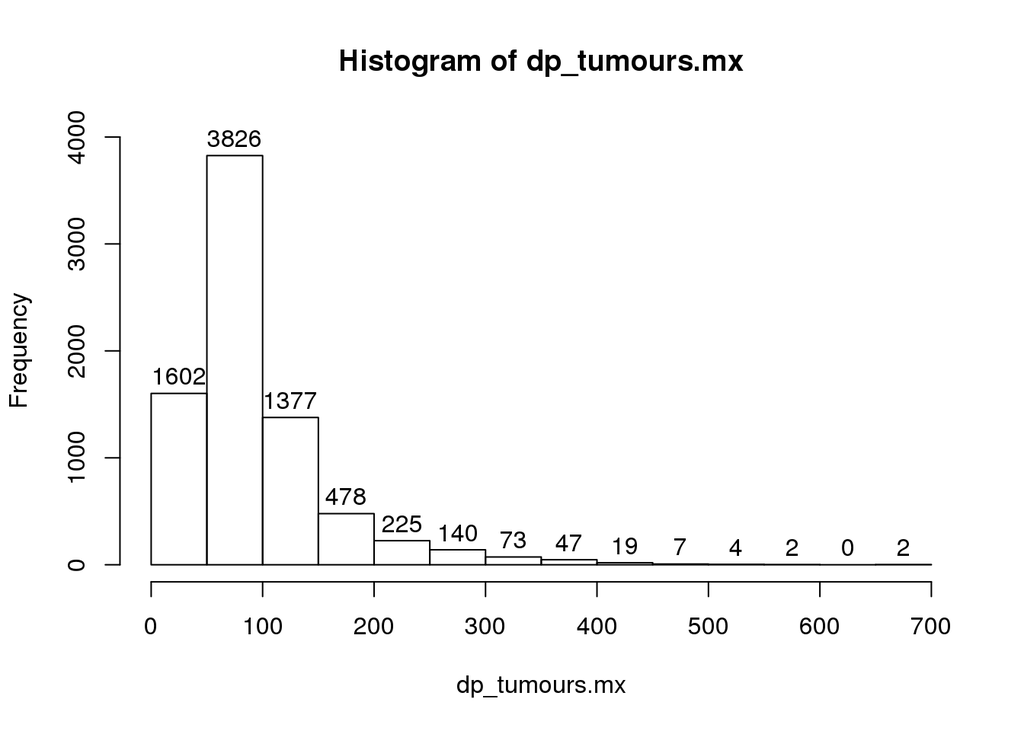

```r
hist(dp_tumours.mx, labels = T, ylim=c(0,4000))
```

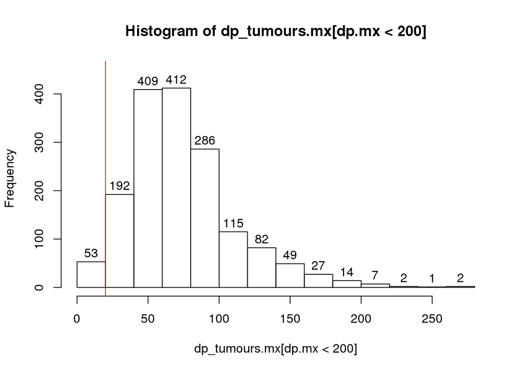

```r
hist(dp_tumours.mx[dp.mx<200], labels = T, ylim=c(0,450))
abline(v=20, col="RED")
```

```r
total <- sum(!is.na(dp_tumours.mx))
total
```

```
## [1] 7802
```

```r
excluded <- 53
excluded
```

```
## [1] 53
```

```r
excluded/total
```

```
## [1] 0.00679313
```

```r
# depth in ref
dp_ref_tumours.mx <- dp_ref.mx[,tumours]
dim(dp_ref_tumours.mx)
```

```
## [1] 7608    4
```

```r
mean(dp_ref_tumours.mx, na.rm=T)
```

```
## [1] 89.51628
```

```r
median(dp_ref_tumours.mx, na.rm=T)
```

```
## [1] 74
```

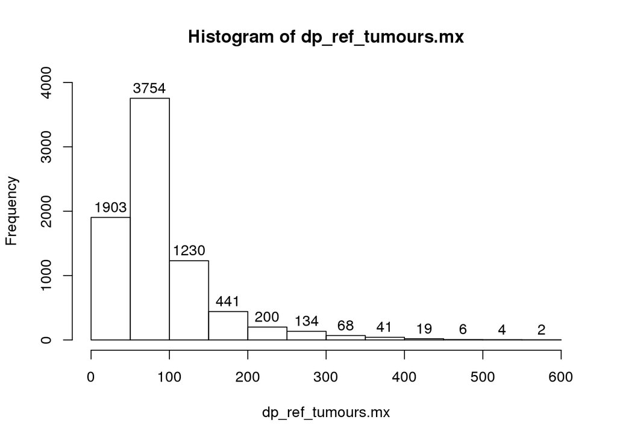

```r
hist(dp_ref_tumours.mx, labels = T, ylim=c(0,4000))
```

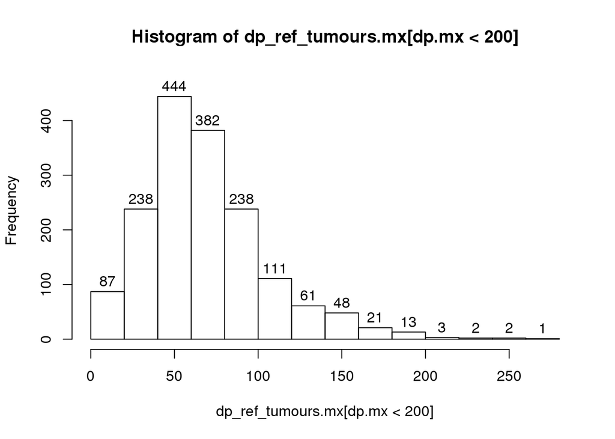

```r
hist(dp_ref_tumours.mx[dp.mx<200], labels = T, ylim=c(0,470))
```

```r
# depth in alt
dp_alt_tumours.mx <- dp_alt.mx[,tumours]
dim(dp_alt_tumours.mx)
```

```
## [1] 7608    4
```

```r
mean(dp_alt_tumours.mx, na.rm=T)
```

```
## [1] 4.506921
```

```r
median(dp_alt_tumours.mx, na.rm=T)
```

```
## [1] 4
```

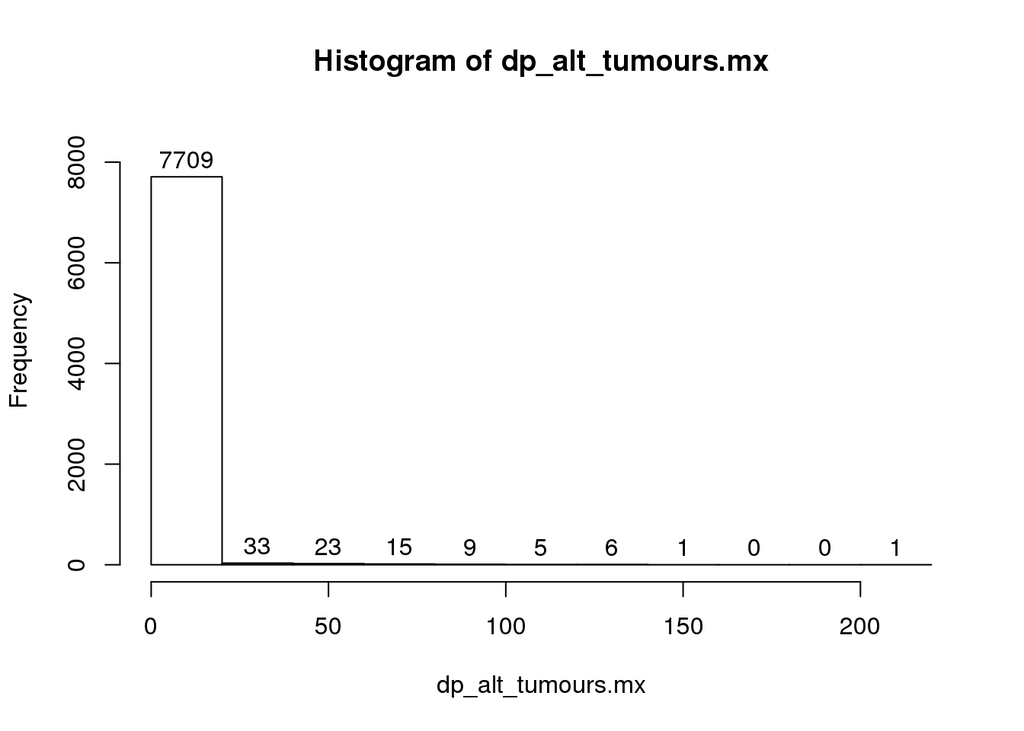

```
##  [1]   0  20  40  60  80 100 120 140 160 180 200 220
```

```r
hist(dp_alt_tumours.mx, labels = T, ylim=c(0,8500))$breaks
```

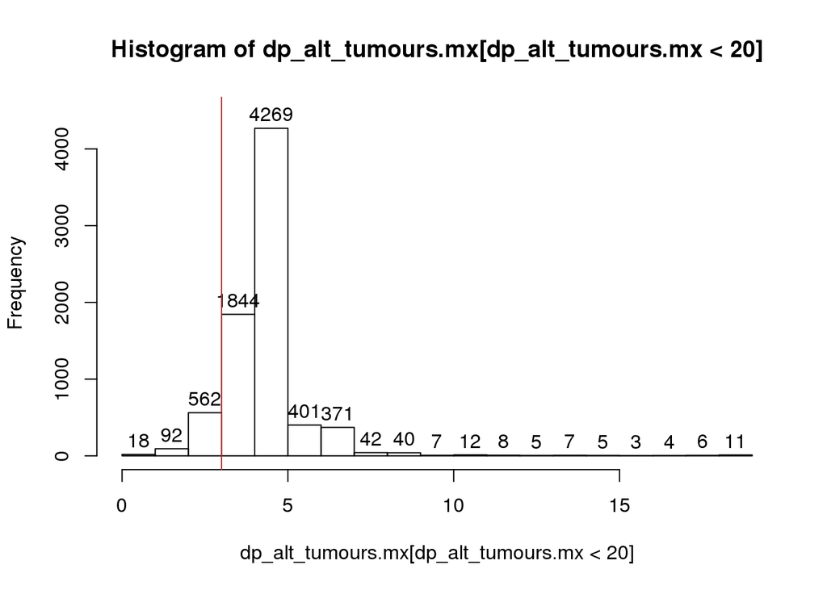

```r
hist(dp_alt_tumours.mx[dp_alt_tumours.mx<20], labels = T, ylim=c(0,4500), right=F) # left-open, right-closed (see ?hist)
abline(v=3, col="RED")
```

```r
table(dp_alt_tumours.mx[dp_alt_tumours.mx<20])
```

```
##
##    0    1    2    3    4    5    6    7    8    9   10   11   12   13   14   15   16   17   18   19
##   18   92  562 1844 4269  401  371   42   40    7   12    8    5    7    5    3    4    6    6    5
```

```r
total <- sum(!is.na(dp_alt_tumours.mx))
total
```

```
## [1] 7802
```

```r
excluded <- 18+92+562
excluded
```

```
## [1] 672
```

```r
excluded/total
```

```
## [1] 0.08613176
```

```r
# --- explore cases with low ALT depth in tumours --- #

# alt in tumours = 0
low_alt_in_tumours <- unique(which(dp_alt_tumours.mx==0)%%nrow(dp_alt_tumours.mx))
ad.df[low_alt_in_tumours,]
```

```
##                SplitVarID IHCAP75_1F_N IHCAP75_1F_T IHCAP75_BM_N IHCAP75_BM_T IHCAP75_T1_N IHCAP75_T1_T IHCAP75_T2_N IHCAP75_T2_T
## Var000005344 Var000005344        110,0         82,0         <NA>         <NA>         <NA>         <NA>         <NA>         <NA>
## Var000001050 Var000001050         <NA>         <NA>         91,1         83,0         <NA>         <NA>         <NA>         <NA>
## Var000001395 Var000001395         <NA>         <NA>        144,1         90,0         <NA>         <NA>         <NA>         <NA>
## Var000002035 Var000002035         <NA>         <NA>         63,1         47,0         <NA>         <NA>         <NA>         <NA>
## Var000003157 Var000003157         <NA>         <NA>         59,0         51,0         <NA>         <NA>         <NA>         <NA>
## Var000005826 Var000005826         <NA>         <NA>         47,0         31,0         <NA>         <NA>         <NA>         <NA>
## Var000000210 Var000000210         <NA>         <NA>         <NA>         <NA>        164,1         64,0         <NA>         <NA>
## Var000001546 Var000001546         <NA>         <NA>         <NA>         <NA>        109,0         15,0         <NA>         <NA>
## Var000002415 Var000002415         <NA>         <NA>         <NA>         <NA>        133,1         80,0         <NA>         <NA>
## Var000002700 Var000002700         <NA>         <NA>         <NA>         <NA>         76,0         26,0         <NA>         <NA>
## Var000002795 Var000002795         <NA>         <NA>         <NA>         <NA>         95,0         36,0         94,0         40,0
## Var000002880 Var000002880         <NA>         <NA>         <NA>         <NA>        206,0         93,0         <NA>         <NA>
## Var000002989 Var000002989         <NA>         <NA>         <NA>         <NA>        270,0        107,0         <NA>         <NA>
## Var000003267 Var000003267         <NA>         <NA>         <NA>         <NA>         90,1         44,0         <NA>         <NA>
## Var000006672 Var000006672         <NA>         <NA>         <NA>         <NA>        158,0        129,0         <NA>         <NA>
## Var000001339 Var000001339         <NA>         <NA>         <NA>         <NA>         <NA>         <NA>         71,1         41,0
## Var000006531 Var000006531         <NA>         <NA>         <NA>         <NA>         <NA>         <NA>         37,0         13,0
```

```r
vv.df[ad.df[low_alt_in_tumours,"SplitVarID"],c("SplitVarID","SYMBOL","Consequence","CLIN_SIG")]
```

```
##                SplitVarID         SYMBOL                          Consequence CLIN_SIG
## Var000005344 Var000005344          TYRO3                       intron_variant     <NA>
## Var000001050 Var000001050          SMPD4                     missense_variant     <NA>
## Var000001395 Var000001395          SCN5A                     missense_variant     <NA>
## Var000002035 Var000002035       FAM160A1 splice_region_variant&intron_variant     <NA>
## Var000003157 Var000003157 RP11-481A20.11 splice_region_variant&intron_variant     <NA>
## Var000005826 Var000005826          CDH15                upstream_gene_variant     <NA>
## Var000000210 Var000000210  RP11-214L19.1   non_coding_transcript_exon_variant     <NA>
## Var000001546 Var000001546        MIR1284              downstream_gene_variant     <NA>
## Var000002415 Var000002415           NQO2                  5_prime_UTR_variant     <NA>
## Var000002700 Var000002700          MED23                     missense_variant     <NA>
## Var000002795 Var000002795          INTS1 splice_region_variant&intron_variant     <NA>
## Var000002880 Var000002880            GCK                       intron_variant     <NA>
## Var000002989 Var000002989          MUC12                     missense_variant     <NA>
## Var000003267 Var000003267        SDR16C5                       intron_variant     <NA>
## Var000006672 Var000006672          CEP89       stop_gained&frameshift_variant     <NA>
## Var000001339 Var000001339          PRRT3                       intron_variant     <NA>
## Var000006531 Var000006531          MUC16                       intron_variant     <NA>
```

```r
# alt in tumours = 1
low_alt_in_tumours <- unique(which(dp_alt_tumours.mx==1)%%nrow(dp_alt_tumours.mx))
ad.df[low_alt_in_tumours,]
```

```
##                SplitVarID IHCAP75_1F_N IHCAP75_1F_T IHCAP75_BM_N IHCAP75_BM_T IHCAP75_T1_N IHCAP75_T1_T IHCAP75_T2_N IHCAP75_T2_T
## Var000000065 Var000000065         29,0         15,1         <NA>         <NA>         <NA>         <NA>         <NA>         <NA>
## Var000000136 Var000000136         61,0         50,1         <NA>         <NA>         <NA>         <NA>         <NA>         <NA>
## Var000000143 Var000000143         61,0         40,1         <NA>         <NA>         <NA>         <NA>         <NA>         <NA>
## Var000000455 Var000000455        265,0        178,1         <NA>         <NA>         <NA>         <NA>         <NA>         <NA>
## Var000000667 Var000000667        239,0        150,1         <NA>         <NA>         <NA>         <NA>         <NA>         <NA>
## Var000000708 Var000000708        323,0        250,1         <NA>         <NA>         <NA>         <NA>         <NA>         <NA>
## Var000002615 Var000002615        146,0        107,1         <NA>         <NA>         <NA>         <NA>         <NA>         <NA>
## Var000003718 Var000003718        191,0        153,1         <NA>         <NA>         <NA>         <NA>         <NA>         <NA>
## Var000004138 Var000004138        269,0        199,1         <NA>         <NA>         <NA>         <NA>         <NA>         <NA>
## Var000004324 Var000004324        147,0         89,1         <NA>         <NA>         <NA>         <NA>         <NA>         <NA>
## Var000005200 Var000005200        136,0        102,1         <NA>         <NA>         <NA>         <NA>         <NA>         <NA>
## Var000005260 Var000005260         94,0         44,1         <NA>         <NA>         <NA>         <NA>         <NA>         <NA>
## Var000000036 Var000000036         <NA>         <NA>        227,0        176,1         <NA>         <NA>         <NA>         <NA>
## Var000001062 Var000001062         <NA>         <NA>        220,0        242,1         <NA>         <NA>         <NA>         <NA>
## Var000001118 Var000001118         <NA>         <NA>        162,0        109,1         <NA>         <NA>         <NA>         <NA>
## Var000001144 Var000001144         <NA>         <NA>        102,0         94,1         <NA>         <NA>         <NA>         <NA>
## Var000001425 Var000001425         <NA>         <NA>         83,0         36,1         <NA>         <NA>         <NA>         <NA>
## Var000001489 Var000001489         <NA>         <NA>        150,0        131,1         <NA>         <NA>         <NA>         <NA>
## Var000001590 Var000001590         <NA>         <NA>         96,0         72,1         <NA>         <NA>         <NA>         <NA>
## Var000001658 Var000001658         <NA>         <NA>        312,0        268,1         <NA>         <NA>         <NA>         <NA>
## Var000001759 Var000001759         <NA>         <NA>        115,0        142,1         <NA>         <NA>         <NA>         <NA>
## Var000001801 Var000001801         <NA>         <NA>        139,0        179,1         <NA>         <NA>         <NA>         <NA>
## Var000001953 Var000001953         <NA>         <NA>         56,0         59,1         <NA>         <NA>         <NA>         <NA>
## Var000001967 Var000001967         <NA>         <NA>        443,0        393,1         <NA>         <NA>         <NA>         <NA>
## Var000002270 Var000002270         <NA>         <NA>        154,0        100,1         <NA>         <NA>         <NA>         <NA>
## Var000003123 Var000003123         <NA>         <NA>        129,0         88,1         <NA>         <NA>         <NA>         <NA>
## Var000003438 Var000003438         <NA>         <NA>         84,0         40,1         <NA>         <NA>         <NA>         <NA>
## Var000003796 Var000003796         <NA>         <NA>        277,0        305,1         <NA>         <NA>         <NA>         <NA>
## Var000004007 Var000004007         <NA>         <NA>         74,0         47,1         <NA>         <NA>         <NA>         <NA>
## Var000004124 Var000004124         <NA>         <NA>        344,0        281,1         <NA>         <NA>         <NA>         <NA>
## Var000004143 Var000004143         <NA>         <NA>        346,0        236,1         <NA>         <NA>         <NA>         <NA>
## Var000004663 Var000004663         <NA>         <NA>        165,0         91,1         <NA>         <NA>         <NA>         <NA>
## Var000004700 Var000004700         <NA>         <NA>        130,0         95,1         <NA>         <NA>         <NA>         <NA>
## Var000004873 Var000004873         <NA>         <NA>        377,0        411,1         <NA>         <NA>         <NA>         <NA>
## Var000005575 Var000005575         <NA>         <NA>        221,0        140,1         <NA>         <NA>         <NA>         <NA>
## Var000005587 Var000005587         <NA>         <NA>         82,0         63,1         <NA>         <NA>         <NA>         <NA>
## Var000006217 Var000006217         <NA>         <NA>         90,0        100,1         <NA>         <NA>         <NA>         <NA>
## Var000006473 Var000006473         <NA>         <NA>         84,0         53,1         <NA>         <NA>         <NA>         <NA>
## Var000006482 Var000006482         <NA>         <NA>        132,0         89,1         <NA>         <NA>         <NA>         <NA>
```

[output cut: 38 more lines]

```
## Var000004352 Var000004352         <NA>         <NA>         <NA>         <NA>         <NA>         <NA>        108,0         45,1
## Var000004420 Var000004420         <NA>         <NA>         <NA>         <NA>         <NA>         <NA>        115,0         65,1
## Var000004454 Var000004454         <NA>         <NA>         <NA>         <NA>         <NA>         <NA>        137,0         80,1
## Var000004592 Var000004592         <NA>         <NA>         <NA>         <NA>         <NA>         <NA>        131,0         77,1
## Var000004721 Var000004721         <NA>         <NA>         <NA>         <NA>         <NA>         <NA>        359,0        203,1
## Var000004723 Var000004723         <NA>         <NA>         <NA>         <NA>         <NA>         <NA>        147,0        109,1
## Var000005329 Var000005329         <NA>         <NA>         <NA>         <NA>         <NA>         <NA>        161,0        135,1
## Var000005380 Var000005380         <NA>         <NA>         <NA>         <NA>         <NA>         <NA>        192,0        106,1
## Var000005384 Var000005384         <NA>         <NA>         <NA>         <NA>         <NA>         <NA>        264,0        154,1
## Var000005723 Var000005723         <NA>         <NA>         <NA>         <NA>         <NA>         <NA>         46,0         22,1
## Var000006107 Var000006107         <NA>         <NA>         <NA>         <NA>         <NA>         <NA>        222,0        182,1
## Var000007022 Var000007022         <NA>         <NA>         <NA>         <NA>         <NA>         <NA>        345,0        217,1
## Var000007401 Var000007401         <NA>         <NA>         <NA>         <NA>         <NA>         <NA>        137,0         70,1
## Var000007445 Var000007445         <NA>         <NA>         <NA>         <NA>         <NA>         <NA>        193,0         73,1
## Var000007531 Var000007531         <NA>         <NA>         <NA>         <NA>         <NA>         <NA>        293,0        109,1
```

```r
vv.df[ad.df[low_alt_in_tumours,"SplitVarID"],c("SplitVarID","SYMBOL","Consequence","CLIN_SIG")]
```

```
##                SplitVarID        SYMBOL                          Consequence      CLIN_SIG
## Var000000065 Var000000065        PTCHD2                   synonymous_variant          <NA>
## Var000000136 Var000000136         MYOM3                       intron_variant          <NA>
## Var000000143 Var000000143        MAN1C1                   synonymous_variant          <NA>
## Var000000455 Var000000455       DENND4B                     inframe_deletion          <NA>
## Var000000667 Var000000667      C1orf116                   frameshift_variant          <NA>
## Var000000708 Var000000708        DNAH14                     missense_variant          <NA>
## Var000002615 Var000002615        ZNF451                       intron_variant          <NA>
## Var000003718 Var000003718   RP1-251M9.3              downstream_gene_variant          <NA>
## Var000004138 Var000004138         FBXO3                   synonymous_variant          <NA>
## Var000004324 Var000004324         C2CD3              downstream_gene_variant          <NA>
## Var000005200 Var000005200         TTLL5                     missense_variant          <NA>
## Var000005260 Var000005260          RTL1                     missense_variant          <NA>
## Var000000036 Var000000036       PLEKHG5                     missense_variant likely_benign
## Var000001062 Var000001062       MAP3K19 splice_region_variant&intron_variant          <NA>
## Var000001118 Var000001118         XIRP2                     missense_variant          <NA>
## Var000001144 Var000001144          MLTK                   synonymous_variant          <NA>
## Var000001425 Var000001425        PRSS50                       intron_variant          <NA>
## Var000001489 Var000001489         PARP3 splice_region_variant&intron_variant          <NA>
## Var000001590 Var000001590          POLQ                     missense_variant          <NA>
## Var000001658 Var000001658         TRPC1                   frameshift_variant          <NA>
## Var000001759 Var000001759         NRROS                   frameshift_variant          <NA>
## Var000001801 Var000001801          EVC2                     missense_variant          <NA>
## Var000001953 Var000001953          AFF1                   frameshift_variant          <NA>
## Var000001967 Var000001967      SMARCAD1                    inframe_insertion          <NA>
## Var000002270 Var000002270          <NA>                   intergenic_variant          <NA>
## Var000003123 Var000003123          NOS3                   frameshift_variant          <NA>
## Var000003438 Var000003438       FAM205A                     missense_variant          <NA>
## Var000003796 Var000003796        PCDH15                    inframe_insertion          <NA>
## Var000004007 Var000004007         SYCE1                            stop_lost          <NA>
## Var000004124 Var000004124          NAV2                   frameshift_variant          <NA>
## Var000004143 Var000004143          PDHX                   frameshift_variant          <NA>
## Var000004663 Var000004663         HOXC8                       intron_variant          <NA>
## Var000004700 Var000004700          LRP1                   frameshift_variant          <NA>
## Var000004873 Var000004873      ATP6V0A2                   synonymous_variant          <NA>
## Var000005575 Var000005575         MMP25                   frameshift_variant          <NA>
## Var000005587 Var000005587        DNAJA3                     missense_variant          <NA>
## Var000006217 Var000006217         NOL11                    inframe_insertion          <NA>
## Var000006473 Var000006473        ZNF554                   frameshift_variant          <NA>
## Var000006482 Var000006482       PIP5K1C                       intron_variant          <NA>
```

[output cut: 38 more lines]

```
## Var000004352 Var000004352          FAT3                   frameshift_variant          <NA>
## Var000004420 Var000004420        AMICA1                       intron_variant          <NA>
## Var000004454 Var000004454       GRAMD1B                   frameshift_variant          <NA>
## Var000004592 Var000004592      ADAMTS20                     missense_variant          <NA>
## Var000004721 Var000004721         GRIP1                   frameshift_variant          <NA>
## Var000004723 Var000004723          MDM1                     missense_variant          <NA>
## Var000005329 Var000005329         NUTM1                   synonymous_variant          <NA>
## Var000005380 Var000005380      C15orf48                  5_prime_UTR_variant          <NA>
## Var000005384 Var000005384        CEP152                       intron_variant          <NA>
## Var000005723 Var000005723         GNAO1                  5_prime_UTR_variant          <NA>
## Var000006107 Var000006107          WNK4                   frameshift_variant          <NA>
## Var000007022 Var000007022       ARFGEF2 splice_region_variant&intron_variant          <NA>
## Var000007401 Var000007401          RBM3                       intron_variant          <NA>
## Var000007445 Var000007445         FOXO4                   frameshift_variant          <NA>
## Var000007531 Var000007531        ATP1B4                     missense_variant          <NA>
```

```r
# Clean-up
rm(tumours, dp_tumours.mx, dp_ref_tumours.mx, dp_alt_tumours.mx, low_alt_in_tumours, total, excluded)
```

# explore alt fraction

Look separately in all, normal(s) and tumours

Suggestion:  
Similar to common practice, keep only variants with alt fraction in tumours > 10%

Note:  
Threshold of 5% or even 1% would do, if we consider histograms only, without following the common practice, however the total numbers of variants increases by 3000!

```r
# alt fraction in all 8 columns - for orientation
mean(alt_fraction.mx, na.rm=T)
```

```
## [1] 0.03337035
```

```r
median(alt_fraction.mx, na.rm=T)
```

```
## [1] 0.01197605
```

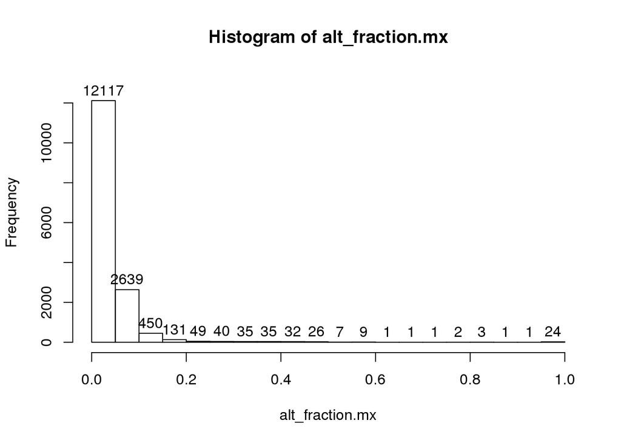

```r
hist(alt_fraction.mx, labels = T, ylim=c(0,13000))
```

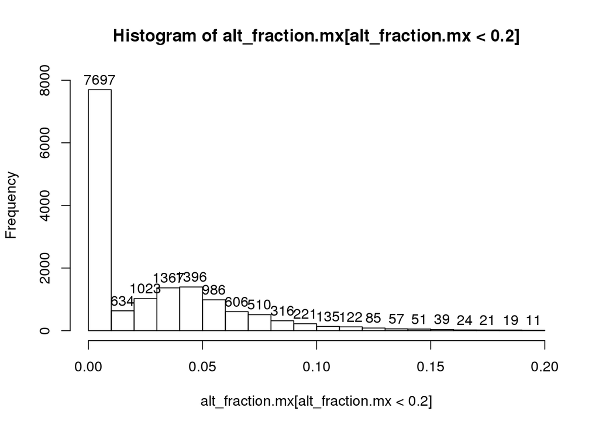

```r
hist(alt_fraction.mx[alt_fraction.mx<0.2], labels = T, ylim=c(0,8000))
```

```r
# alt fraction in normals (typically < 0.5%)
normals <- c("IHCAP75_1F_N", "IHCAP75_BM_N", "IHCAP75_T1_N", "IHCAP75_T2_N")
alt_fraction_normals.mx <- alt_fraction.mx[,normals]
mean(alt_fraction_normals.mx, na.rm=T)
```

```
## [1] 0.001318226
```

```r
median(alt_fraction_normals.mx, na.rm=T)
```

```
## [1] 0
```

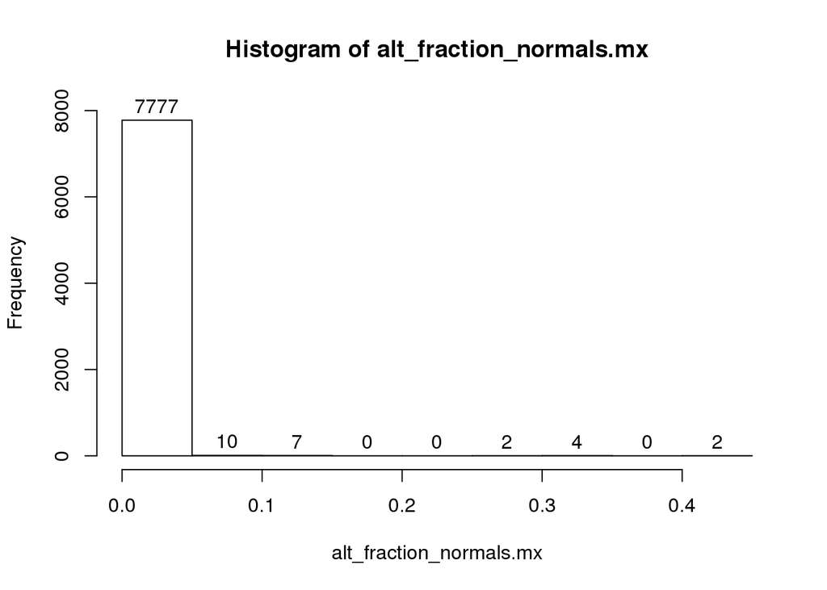

```r
hist(alt_fraction_normals.mx, labels = T, ylim=c(0,8000))
```

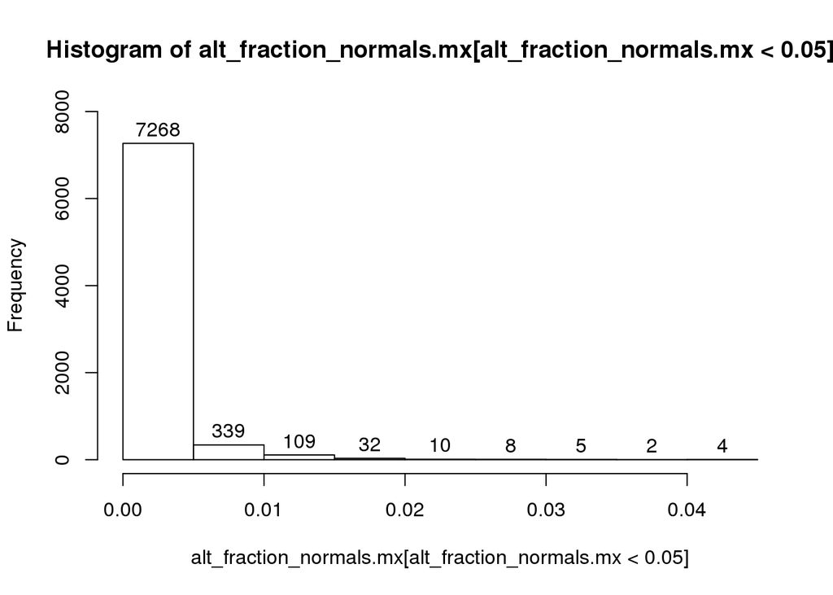

```r
hist(alt_fraction_normals.mx[alt_fraction_normals.mx<0.05], labels = T, ylim=c(0,8000))
```

```r
# alt fraction in tumours (typically > 1%)
tumours <- c("IHCAP75_1F_T", "IHCAP75_BM_T", "IHCAP75_T1_T", "IHCAP75_T2_T")
alt_fraction_tumours.mx <- alt_fraction.mx[,tumours]
mean(alt_fraction_tumours.mx, na.rm=T)
```

```
## [1] 0.06542248
```

```r
median(alt_fraction_tumours.mx, na.rm=T)
```

```
## [1] 0.04705882
```

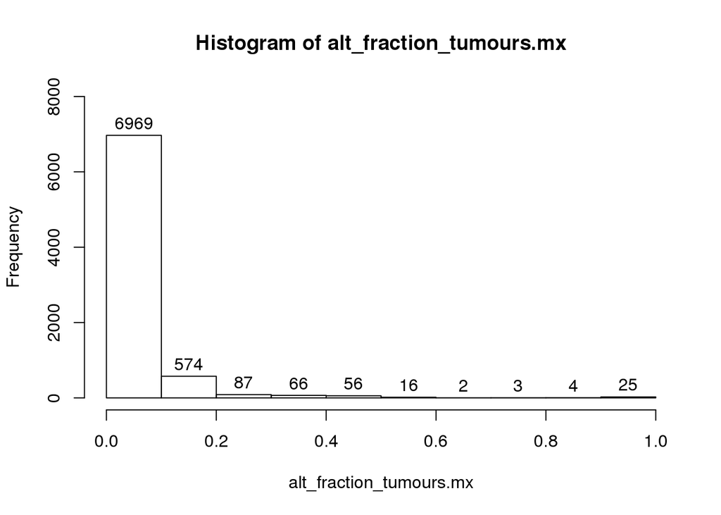

```r
hist(alt_fraction_tumours.mx, labels = T, ylim=c(0,8000))
```

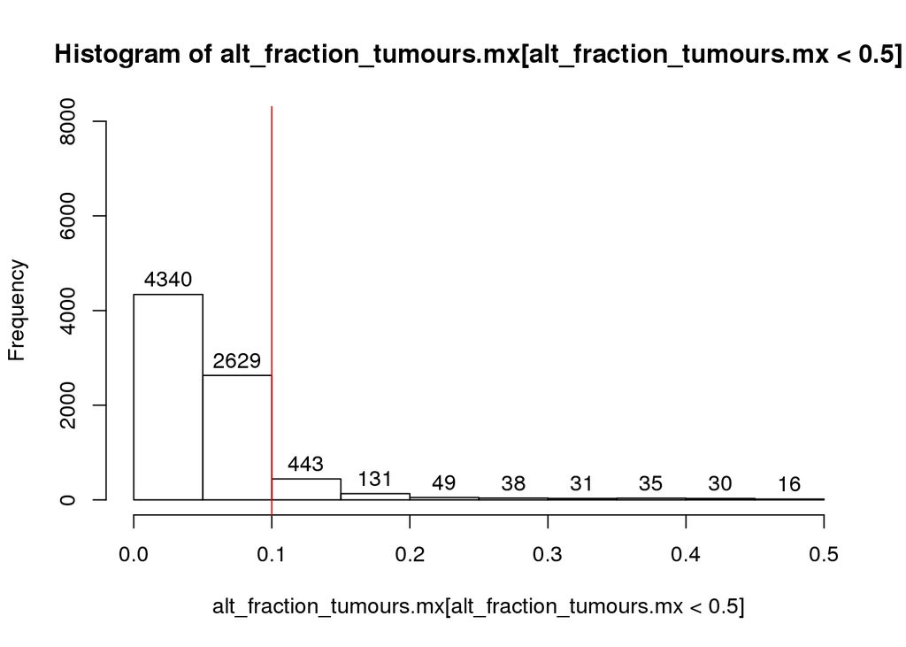

```r
hist(alt_fraction_tumours.mx[alt_fraction_tumours.mx<0.5], labels = T, ylim=c(0,8000))
abline(v=0.1, col="red")
```

```r
total <- sum(!is.na(alt_fraction_tumours.mx))
total
```

```
## [1] 7802
```

```r
excluded <- 4340 + 2629
excluded
```

```
## [1] 6969
```

```r
excluded/total
```

```
## [1] 0.8932325
```

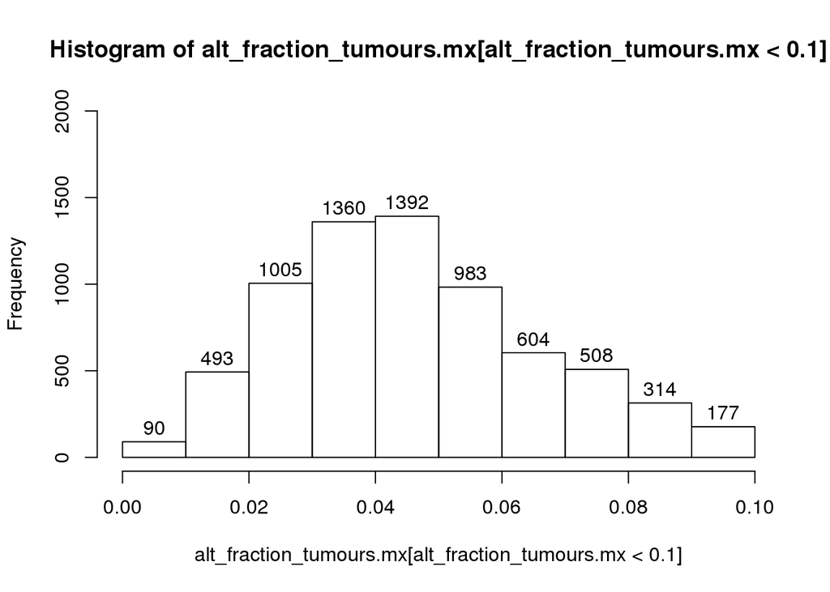

```r
hist(alt_fraction_tumours.mx[alt_fraction_tumours.mx<0.1], labels = T, ylim=c(0,2000))
```

```r
rm(normals, tumours, alt_fraction_normals.mx, alt_fraction_tumours.mx, total, excluded)
```

# select unfiltered variants present in multiple samples

```r
call_count.udf <- function(gt_vector){sum(!is.na(gt_vector))}
call_counts <- apply(gt_add.df,1,call_count.udf)
table(call_counts)
```

```
## call_counts
##    2    4    6    8
## 7494   67   14   33
```

```r
# Index of variants present in single sample only
single_sample_variants <- call_counts == 2
sum(!single_sample_variants)
```

```
## [1] 114
```

```r
# Tables with variants detected in multiple samples
gt_raw_multi_sample.df <- gt_add.df[!single_sample_variants,]
dim(gt_raw_multi_sample.df)
```

```
## [1] 114   8
```

```r
vv_raw_multi_sample.df <- vv.df[!single_sample_variants,]
dim(vv_raw_multi_sample.df)
```

```
## [1] 114  60
```

```r
ad_raw_multi_sample.df <- ad.df[!single_sample_variants,]
dim(ad_raw_multi_sample.df)
```

```
## [1] 114   9
```

```r
dp_raw_multi_sample.mx <- dp.mx[!single_sample_variants,]
dim(dp_raw_multi_sample.mx)
```

```
## [1] 114   8
```

```r
dp_raw_ref_multi_sample.mx <- dp_ref.mx[!single_sample_variants,]
dim(dp_raw_ref_multi_sample.mx)
```

```
## [1] 114   8
```

```r
dp_raw_alt_multi_sample.mx <- dp_alt.mx[!single_sample_variants,]
dim(dp_raw_alt_multi_sample.mx)
```

```
## [1] 114   8
```

```r
alt_raw_fraction_multi_sample.mx <- alt_fraction.mx[!single_sample_variants,]
dim(alt_raw_fraction_multi_sample.mx)
```

```
## [1] 114   8
```

```r
# clean-up
rm(single_sample_variants, call_counts, call_count.udf)
```

# save_results

```r
save.image("s01_explore_source.RData")
```

# final_section

```r
ls()
```

[output not shown]

```r
Sys.time()
```

```
## [1] "2018-05-25 16:11:54 BST"
```